# Bank Churn Prediction

## Objective:

Given a Bank customer, build a neural network based classifier that can determine whether they will leave or not in the next 6 months

## Context:

Businesses like banks which provide service have to worry about problem of 'Churn' i.e. customers leaving and joining another service provider. It is important to understand which aspects of the service influence a customer's decision in this regard. Management can concentrate efforts on improvement of service, keeping in mind these priorities.

## Data Description:

The case study is from an open-source dataset from Kaggle.The dataset contains 10,000 sample points with 14 distinct features such as CustomerId,CreditScore, Geography, Gender, Age, Tenure, Balance etc.

Link to the Kaggle project site: https://www.kaggle.com/barelydedicated/bank-customer-churn-modeling

## https://github.com/GreatLearningAIML1/gl-pgp-aiml-uta-intl-apr20-SubratMuruni.git

## Deliverable – 1: Read the dataset (No Marks)

**1.1 Import necessary Python Libraries**

```python
# Import all essential python libraries

import pandas as pd  #importing Pandas
import numpy as np  # importing Numpy
import scipy.stats as stats # importing Scipy for statistical operations
import matplotlib.pyplot as plt # importing Matplotlib
import seaborn as sns # importing Seaborn
sns.set(color_codes = True) # setting the background of the visualization graph
%matplotlib inline
import warnings
warnings.filterwarnings('ignore')
from sklearn.model_selection import train_test_split
from sklearn import preprocessing
import tensorflow as tf
from tensorflow.keras.models import Sequential
from tensorflow.keras.layers import Dense
# importing metrics for calculating the scores
from sklearn.metrics import accuracy_score, confusion_matrix, precision_score, recall_score, f1_score, precision_recall_curve, roc_auc_score, roc_curve
from tensorflow.keras import optimizers
from sklearn.model_selection import GridSearchCV
from keras.wrappers.scikit_learn import KerasClassifier
from keras.layers import Dropout
from keras.constraints import maxnorm
from keras.optimizers import SGD
```

**1.2 General characteristic of the dataset**

```python
# read the dataset into a dataframe
dfBankCustBase = pd.read_csv('/Users/subratmuruni/desktop/Data Science/Projects_Assignments/Project_dataset/bank.csv')
```

```python
# read the first 5 rows of the dataset
dfBankCustBase.head()
```

|  | RowNumber | CustomerId | Surname | CreditScore | Geography | Gender | Age | Tenure | Balance | NumOfProducts | HasCrCard | IsActiveMember | EstimatedSalary | Exited |
| --- | --- | --- | --- | --- | --- | --- | --- | --- | --- | --- | --- | --- | --- | --- |
| 0 | 1 | 15634602 | Hargrave | 619 | France | Female | 42 | 2 | 0.00 | 1 | 1 | 1 | 101348.88 | 1 |
| 1 | 2 | 15647311 | Hill | 608 | Spain | Female | 41 | 1 | 83807.86 | 1 | 0 | 1 | 112542.58 | 0 |
| 2 | 3 | 15619304 | Onio | 502 | France | Female | 42 | 8 | 159660.80 | 3 | 1 | 0 | 113931.57 | 1 |
| 3 | 4 | 15701354 | Boni | 699 | France | Female | 39 | 1 | 0.00 | 2 | 0 | 0 | 93826.63 | 0 |
| 4 | 5 | 15737888 | Mitchell | 850 | Spain | Female | 43 | 2 | 125510.82 | 1 | 1 | 1 | 79084.10 | 0 |

```python
# read the last 5 rows of the dataset
dfBankCustBase.tail()
```

|  | RowNumber | CustomerId | Surname | CreditScore | Geography | Gender | Age | Tenure | Balance | NumOfProducts | HasCrCard | IsActiveMember | EstimatedSalary | Exited |
| --- | --- | --- | --- | --- | --- | --- | --- | --- | --- | --- | --- | --- | --- | --- |
| 9995 | 9996 | 15606229 | Obijiaku | 771 | France | Male | 39 | 5 | 0.00 | 2 | 1 | 0 | 96270.64 | 0 |
| 9996 | 9997 | 15569892 | Johnstone | 516 | France | Male | 35 | 10 | 57369.61 | 1 | 1 | 1 | 101699.77 | 0 |
| 9997 | 9998 | 15584532 | Liu | 709 | France | Female | 36 | 7 | 0.00 | 1 | 0 | 1 | 42085.58 | 1 |
| 9998 | 9999 | 15682355 | Sabbatini | 772 | Germany | Male | 42 | 3 | 75075.31 | 2 | 1 | 0 | 92888.52 | 1 |
| 9999 | 10000 | 15628319 | Walker | 792 | France | Female | 28 | 4 | 130142.79 | 1 | 1 | 0 | 38190.78 | 0 |

```python
# find the rows and columns of the dataframe
dfBankCustBase.shape # dataset has 10000 rows and 14 columns
```

```
(10000, 14)
```

```python
# columns of the dataset
col = dfBankCustBase.columns
col
```

```
Index(['RowNumber', 'CustomerId', 'Surname', 'CreditScore', 'Geography',
       'Gender', 'Age', 'Tenure', 'Balance', 'NumOfProducts', 'HasCrCard',
       'IsActiveMember', 'EstimatedSalary', 'Exited'],
      dtype='object')
```

```python
# information of the dataset with regards to columns, count and datatype
dfBankCustBase.info()
```

```
<class 'pandas.core.frame.DataFrame'>
RangeIndex: 10000 entries, 0 to 9999
Data columns (total 14 columns):
 #   Column           Non-Null Count  Dtype
---  ------           --------------  -----
 0   RowNumber        10000 non-null  int64
 1   CustomerId       10000 non-null  int64
 2   Surname          10000 non-null  object
 3   CreditScore      10000 non-null  int64
 4   Geography        10000 non-null  object
 5   Gender           10000 non-null  object
 6   Age              10000 non-null  int64
 7   Tenure           10000 non-null  int64
 8   Balance          10000 non-null  float64
 9   NumOfProducts    10000 non-null  int64
 10  HasCrCard        10000 non-null  int64
 11  IsActiveMember   10000 non-null  int64
 12  EstimatedSalary  10000 non-null  float64
 13  Exited           10000 non-null  int64
dtypes: float64(2), int64(9), object(3)
memory usage: 1.1+ MB
```

**1.3 Datatype, Central Value, IQR, standard Deviation**

```python
# datatype of the columns of the dataset
dfBankCustBase.dtypes
```

```
RowNumber            int64
CustomerId           int64
Surname             object
CreditScore          int64
Geography           object
Gender              object
Age                  int64
Tenure               int64
Balance            float64
NumOfProducts        int64
HasCrCard            int64
IsActiveMember       int64
EstimatedSalary    float64
Exited               int64
dtype: object
```

```python
# find the mean of the columns of the dataset
dfBankCustBase.mean()
```

```
RowNumber          5.000500e+03
CustomerId         1.569094e+07
CreditScore        6.505288e+02
Age                3.892180e+01
Tenure             5.012800e+00
Balance            7.648589e+04
NumOfProducts      1.530200e+00
HasCrCard          7.055000e-01
IsActiveMember     5.151000e-01
EstimatedSalary    1.000902e+05
Exited             2.037000e-01
dtype: float64
```

```python
# find the median of the columns of the dataset
dfBankCustBase.median()
```

```
RowNumber          5.000500e+03
CustomerId         1.569074e+07
CreditScore        6.520000e+02
Age                3.700000e+01
Tenure             5.000000e+00
Balance            9.719854e+04
NumOfProducts      1.000000e+00
HasCrCard          1.000000e+00
IsActiveMember     1.000000e+00
EstimatedSalary    1.001939e+05
Exited             0.000000e+00
dtype: float64
```

```python
# find the mode of the columns of the dataset
# dropping the RowNumber, CustomerId and Surname columns as these are unique to customers
dfBankCustBase_1 = dfBankCustBase.drop(['RowNumber', 'CustomerId', 'Surname'],axis=1)

dfBankCustBase_1.mode()
```

|  | CreditScore | Geography | Gender | Age | Tenure | Balance | NumOfProducts | HasCrCard | IsActiveMember | EstimatedSalary | Exited |
| --- | --- | --- | --- | --- | --- | --- | --- | --- | --- | --- | --- |
| 0 | 850 | France | Male | 37 | 2 | 0.0 | 1 | 1 | 1 | 24924.92 | 0 |

```python
# find the standard deviation of the continuous variables
dfBankCustBase_1.std()
```

```
CreditScore           96.653299
Age                   10.487806
Tenure                 2.892174
Balance            62397.405202
NumOfProducts          0.581654
HasCrCard              0.455840
IsActiveMember         0.499797
EstimatedSalary    57510.492818
Exited                 0.402769
dtype: float64
```

```python
# find interquartile range of the dataset
Q1 = dfBankCustBase_1.quantile(0.25)
Q3 = dfBankCustBase_1.quantile(0.75)
IQR = Q3 - Q1
IQR # gives the IQR of continuous variables
```

```
CreditScore           134.0000
Age                    12.0000
Tenure                  4.0000
Balance            127644.2400
NumOfProducts           1.0000
HasCrCard               1.0000
IsActiveMember          1.0000
EstimatedSalary     98386.1375
Exited                  0.0000
dtype: float64
```

**1.4 Missing values, Null values and incorrect imputation**

```python
# check the missing values/null in the dataset
dfBankCustBase.isnull().sum() # there are no missing values and null values in the dataset
```

```
RowNumber          0
CustomerId         0
Surname            0
CreditScore        0
Geography          0
Gender             0
Age                0
Tenure             0
Balance            0
NumOfProducts      0
HasCrCard          0
IsActiveMember     0
EstimatedSalary    0
Exited             0
dtype: int64
```

```python
# find null values in the dataset
dfBankCustBase.isnull().any() # all columns indicate false which means no missing values
```

```
RowNumber          False
CustomerId         False
Surname            False
CreditScore        False
Geography          False
Gender             False
Age                False
Tenure             False
Balance            False
NumOfProducts      False
HasCrCard          False
IsActiveMember     False
EstimatedSalary    False
Exited             False
dtype: bool
```

```python
# check for values that are NaN/NA
dfBankCustBase.isna().sum() # there are no values as Na or NaN
```

```
RowNumber          0
CustomerId         0
Surname            0
CreditScore        0
Geography          0
Gender             0
Age                0
Tenure             0
Balance            0
NumOfProducts      0
HasCrCard          0
IsActiveMember     0
EstimatedSalary    0
Exited             0
dtype: int64
```

```python
# find NaN/NA or improper values in the dataset
dfBankCustBase.isna().any() # false indicates no Na or NaN values in the dataset
```

```
RowNumber          False
CustomerId         False
Surname            False
CreditScore        False
Geography          False
Gender             False
Age                False
Tenure             False
Balance            False
NumOfProducts      False
HasCrCard          False
IsActiveMember     False
EstimatedSalary    False
Exited             False
dtype: bool
```

```python
# find duplicates in the dataset
dfBankCustBase.duplicated().sum() # there are 0 duplicate rows in the dataframe
```

```
0
```

```python
# dropping categorical columns from the dataset
dfBankCustBase_2 = dfBankCustBase_1.drop(['Geography','Gender'],axis=1)
```

```python
# find whether all values in numerical columns are real or not
dfBankCustBase_2[~dfBankCustBase_2.applymap(np.isreal).all(1)]# all numerical columns have real values
```

|  | CreditScore | Age | Tenure | Balance | NumOfProducts | HasCrCard | IsActiveMember | EstimatedSalary | Exited |
| --- | --- | --- | --- | --- | --- | --- | --- | --- | --- |

```python
# describe the summary of the dataframe
dfBankCustBase_2.describe()
```

|  | CreditScore | Age | Tenure | Balance | NumOfProducts | HasCrCard | IsActiveMember | EstimatedSalary | Exited |
| --- | --- | --- | --- | --- | --- | --- | --- | --- | --- |
| count | 10000.000000 | 10000.000000 | 10000.000000 | 10000.000000 | 10000.000000 | 10000.00000 | 10000.000000 | 10000.000000 | 10000.000000 |
| mean | 650.528800 | 38.921800 | 5.012800 | 76485.889288 | 1.530200 | 0.70550 | 0.515100 | 100090.239881 | 0.203700 |
| std | 96.653299 | 10.487806 | 2.892174 | 62397.405202 | 0.581654 | 0.45584 | 0.499797 | 57510.492818 | 0.402769 |
| min | 350.000000 | 18.000000 | 0.000000 | 0.000000 | 1.000000 | 0.00000 | 0.000000 | 11.580000 | 0.000000 |
| 25% | 584.000000 | 32.000000 | 3.000000 | 0.000000 | 1.000000 | 0.00000 | 0.000000 | 51002.110000 | 0.000000 |
| 50% | 652.000000 | 37.000000 | 5.000000 | 97198.540000 | 1.000000 | 1.00000 | 1.000000 | 100193.915000 | 0.000000 |
| 75% | 718.000000 | 44.000000 | 7.000000 | 127644.240000 | 2.000000 | 1.00000 | 1.000000 | 149388.247500 | 0.000000 |
| max | 850.000000 | 92.000000 | 10.000000 | 250898.090000 | 4.000000 | 1.00000 | 1.000000 | 199992.480000 | 1.000000 |

```python
# find the number of unique values of variables
dfBankCustBase.nunique()
```

```
RowNumber          10000
CustomerId         10000
Surname             2932
CreditScore          460
Geography              3
Gender                 2
Age                   70
Tenure                11
Balance             6382
NumOfProducts          4
HasCrCard              2
IsActiveMember         2
EstimatedSalary     9999
Exited                 2
dtype: int64
```

```python
# find the unique values of the variables
print(dfBankCustBase['Geography'].unique())
print()
print(dfBankCustBase['Gender'].unique())
print()
print(dfBankCustBase['Tenure'].unique())
print()
print(dfBankCustBase['NumOfProducts'].unique())
```

```
['France' 'Spain' 'Germany']

['Female' 'Male']

[ 2  1  8  7  4  6  3 10  5  9  0]

[1 3 2 4]
```

```python
# check the skewness of the continuous variables
dfBankCustBase.skew()
```

```
RowNumber          0.000000
CustomerId         0.001149
CreditScore       -0.071607
Age                1.011320
Tenure             0.010991
Balance           -0.141109
NumOfProducts      0.745568
HasCrCard         -0.901812
IsActiveMember    -0.060437
EstimatedSalary    0.002085
Exited             1.471611
dtype: float64
```

**1.5 Univariate Analysis**

**1.5.1 Histogram plots for the variables in the dataframe**

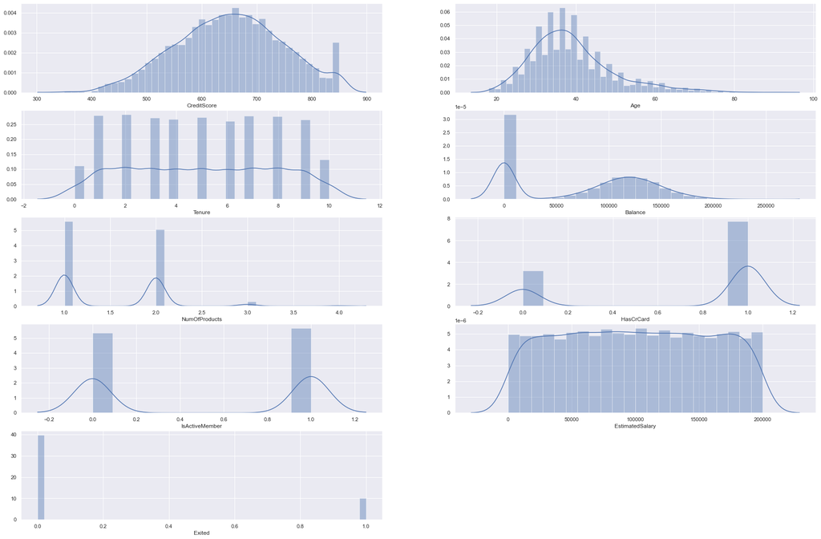

```python
# plot distplot for the continuous variables
plt.figure(figsize=(30,20))
pos = 1
columns = dfBankCustBase_2.columns

for i in columns:
    plt.subplot(5,2,pos)
    sns.distplot(dfBankCustBase_2[i],kde=True)
    # plt.legend().remove()
    pos += 1
plt.show();
```

**1.5.2 Box plots for the variables in the dataframe**

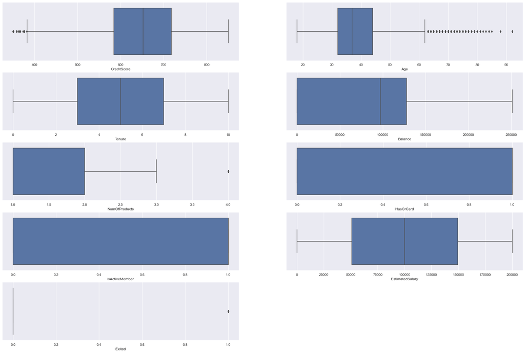

```python
# plot boxplot for the continuous variables
plt.figure(figsize=(30,20))
pos = 1
columns = dfBankCustBase_2.columns

for i in columns:
    plt.subplot(5,2,pos)
    sns.boxplot(x = dfBankCustBase_2[i])
    # plt.legend().remove()
    pos += 1
plt.show();
```

**1.5.3 Heatmap between variables**

```python
# correlation between attributes
corr = dfBankCustBase_2.corr() # assigning variable corr as the correlation function output

corr
```

|  | CreditScore | Age | Tenure | Balance | NumOfProducts | HasCrCard | IsActiveMember | EstimatedSalary | Exited |
| --- | --- | --- | --- | --- | --- | --- | --- | --- | --- |
| CreditScore | 1.000000 | -0.003965 | 0.000842 | 0.006268 | 0.012238 | -0.005458 | 0.025651 | -0.001384 | -0.027094 |
| Age | -0.003965 | 1.000000 | -0.009997 | 0.028308 | -0.030680 | -0.011721 | 0.085472 | -0.007201 | 0.285323 |
| Tenure | 0.000842 | -0.009997 | 1.000000 | -0.012254 | 0.013444 | 0.022583 | -0.028362 | 0.007784 | -0.014001 |
| Balance | 0.006268 | 0.028308 | -0.012254 | 1.000000 | -0.304180 | -0.014858 | -0.010084 | 0.012797 | 0.118533 |
| NumOfProducts | 0.012238 | -0.030680 | 0.013444 | -0.304180 | 1.000000 | 0.003183 | 0.009612 | 0.014204 | -0.047820 |
| HasCrCard | -0.005458 | -0.011721 | 0.022583 | -0.014858 | 0.003183 | 1.000000 | -0.011866 | -0.009933 | -0.007138 |
| IsActiveMember | 0.025651 | 0.085472 | -0.028362 | -0.010084 | 0.009612 | -0.011866 | 1.000000 | -0.011421 | -0.156128 |
| EstimatedSalary | -0.001384 | -0.007201 | 0.007784 | 0.012797 | 0.014204 | -0.009933 | -0.011421 | 1.000000 | 0.012097 |
| Exited | -0.027094 | 0.285323 | -0.014001 | 0.118533 | -0.047820 | -0.007138 | -0.156128 | 0.012097 | 1.000000 |

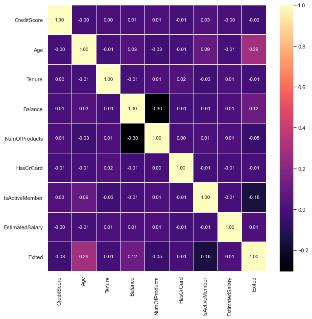

```python
# plot heatmap for the correlation between variables
plt.figure(figsize=(10,10))

sns.heatmap(corr, annot=True, linewidth=0.05, fmt='0.2f',cmap ='magma');
plt.show()
```

**1.5.4 Pair Plot between variables**

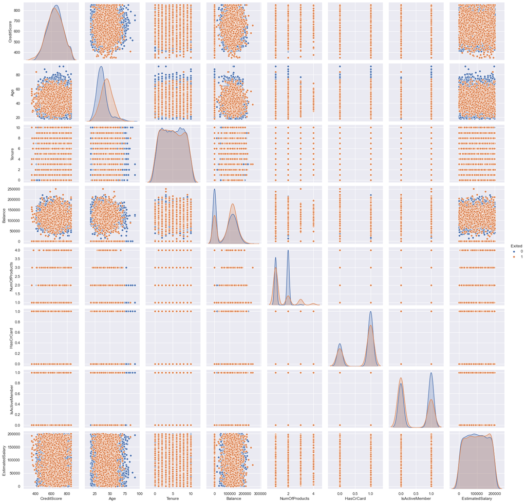

```python
# plot the pairplot between variables with diagonal as KDE
plt.figure(figsize=(8,8))
sns.pairplot(dfBankCustBase_2, diag_kind='kde', hue ='Exited')
plt.show();
```

## Deliverable – 2: Drop the columns which are unique for all users like IDs (5 points)

1. Drop columns RowNumber, CustomerId and Surname from the dataset
2. Categorical columns Geography and Gender will be One-Hot Encoded
3. Identify the class distribution in the data set.

**2.1 Drop columns unique for all users**

```python
# identifying the columns that are unique for all users
dfBankCustBase.columns
```

```
Index(['RowNumber', 'CustomerId', 'Surname', 'CreditScore', 'Geography',
       'Gender', 'Age', 'Tenure', 'Balance', 'NumOfProducts', 'HasCrCard',
       'IsActiveMember', 'EstimatedSalary', 'Exited'],
      dtype='object')
```

```python
# dropping columns RowNumber, CustomerId, Surname
dfBankCustBase_1 = dfBankCustBase.drop(['RowNumber', 'CustomerId', 'Surname'],axis=1)
dfBankCustBase_1.head()
```

|  | CreditScore | Geography | Gender | Age | Tenure | Balance | NumOfProducts | HasCrCard | IsActiveMember | EstimatedSalary | Exited |
| --- | --- | --- | --- | --- | --- | --- | --- | --- | --- | --- | --- |
| 0 | 619 | France | Female | 42 | 2 | 0.00 | 1 | 1 | 1 | 101348.88 | 1 |
| 1 | 608 | Spain | Female | 41 | 1 | 83807.86 | 1 | 0 | 1 | 112542.58 | 0 |
| 2 | 502 | France | Female | 42 | 8 | 159660.80 | 3 | 1 | 0 | 113931.57 | 1 |
| 3 | 699 | France | Female | 39 | 1 | 0.00 | 2 | 0 | 0 | 93826.63 | 0 |
| 4 | 850 | Spain | Female | 43 | 2 | 125510.82 | 1 | 1 | 1 | 79084.10 | 0 |

**2.2 One-Hot Encoding of categorical variables**

```python
# use get_dummies function for categorical columns Geography and Gender
# drop the first column of the one-hot encoded variables
dfBankCustBase_1 = pd.get_dummies(dfBankCustBase_1,drop_first=True)
```

```python
# find the shape of the dataframe after one hot encoding
dfBankCustBase_1.shape
```

```
(10000, 12)
```

```python
# check that there are not object or categorical datatypes being fed to the model.
dfBankCustBase_1.info()
```

```
<class 'pandas.core.frame.DataFrame'>
RangeIndex: 10000 entries, 0 to 9999
Data columns (total 12 columns):
 #   Column             Non-Null Count  Dtype
---  ------             --------------  -----
 0   CreditScore        10000 non-null  int64
 1   Age                10000 non-null  int64
 2   Tenure             10000 non-null  int64
 3   Balance            10000 non-null  float64
 4   NumOfProducts      10000 non-null  int64
 5   HasCrCard          10000 non-null  int64
 6   IsActiveMember     10000 non-null  int64
 7   EstimatedSalary    10000 non-null  float64
 8   Exited             10000 non-null  int64
 9   Geography_Germany  10000 non-null  uint8
 10  Geography_Spain    10000 non-null  uint8
 11  Gender_Male        10000 non-null  uint8
dtypes: float64(2), int64(7), uint8(3)
memory usage: 732.5 KB
```

```python
# check the resulting dataframe
dfBankCustBase_1.head()
```

|  | CreditScore | Age | Tenure | Balance | NumOfProducts | HasCrCard | IsActiveMember | EstimatedSalary | Exited | Geography_Germany | Geography_Spain | Gender_Male |
| --- | --- | --- | --- | --- | --- | --- | --- | --- | --- | --- | --- | --- |
| 0 | 619 | 42 | 2 | 0.00 | 1 | 1 | 1 | 101348.88 | 1 | 0 | 0 | 0 |
| 1 | 608 | 41 | 1 | 83807.86 | 1 | 0 | 1 | 112542.58 | 0 | 0 | 1 | 0 |
| 2 | 502 | 42 | 8 | 159660.80 | 3 | 1 | 0 | 113931.57 | 1 | 0 | 0 | 0 |
| 3 | 699 | 39 | 1 | 0.00 | 2 | 0 | 0 | 93826.63 | 0 | 0 | 0 | 0 |
| 4 | 850 | 43 | 2 | 125510.82 | 1 | 1 | 1 | 79084.10 | 0 | 0 | 1 | 0 |

**2.3 Find whether there is class imbalance in the dataset**

```python
# finding the count of class distribution in the dataset
dfBankCustBase_1.groupby(['Exited']).count()
```

| Exited | CreditScore | Age | Tenure | Balance | NumOfProducts | HasCrCard | IsActiveMember | EstimatedSalary | Geography_Germany | Geography_Spain | Gender_Male |
| --- | --- | --- | --- | --- | --- | --- | --- | --- | --- | --- | --- |
| 0 | 7963 | 7963 | 7963 | 7963 | 7963 | 7963 | 7963 | 7963 | 7963 | 7963 | 7963 |
| 1 | 2037 | 2037 | 2037 | 2037 | 2037 | 2037 | 2037 | 2037 | 2037 | 2037 | 2037 |

```python
# finding out if the dataset is balanced or imbalanced

dfBankCustBase_1['Exited'].value_counts(normalize=True)*100
```

```
0    79.63
1    20.37
Name: Exited, dtype: float64
```

**The resulting data model is a imbalanced data set with class-1 at 20% and class-0 at 79%. Analysis must be done to improve the data model balance and see if class-1 % can be improved.**

Upsampling may be considered for the dataset using SMOTE

## Deliverable – 3: Distinguish the features and target variable(5 points)

**3.1 Separate the independent variables from the dependent variable**

```python
# distinguishing the indepedent variables (features) from the target variable
# all independent variables
X = dfBankCustBase_1.drop('Exited', axis=1)

# Exited column which is dependent variable
y = dfBankCustBase_1['Exited']
```

**3.2 Check the resulting dataframe of the features and series of the target variable**

```python
# check the resulting shape of the independent variables and the target variable
print(X.shape)
print()
print(y.shape)
```

```
(10000, 11)

(10000,)
```

```python
# check the resulting dataframe for the independent variables
X.head()
```

|  | CreditScore | Age | Tenure | Balance | NumOfProducts | HasCrCard | IsActiveMember | EstimatedSalary | Geography_Germany | Geography_Spain | Gender_Male |
| --- | --- | --- | --- | --- | --- | --- | --- | --- | --- | --- | --- |
| 0 | 619 | 42 | 2 | 0.00 | 1 | 1 | 1 | 101348.88 | 0 | 0 | 0 |
| 1 | 608 | 41 | 1 | 83807.86 | 1 | 0 | 1 | 112542.58 | 0 | 1 | 0 |
| 2 | 502 | 42 | 8 | 159660.80 | 3 | 1 | 0 | 113931.57 | 0 | 0 | 0 |
| 3 | 699 | 39 | 1 | 0.00 | 2 | 0 | 0 | 93826.63 | 0 | 0 | 0 |
| 4 | 850 | 43 | 2 | 125510.82 | 1 | 1 | 1 | 79084.10 | 0 | 1 | 0 |

```python
# check the target variable
y.head()
```

```
0    1
1    0
2    1
3    0
4    0
Name: Exited, dtype: int64
```

## Deliverable – 4: Divide the data set into training and test sets (5 points)

**4.1 Split the data into training and test set taking 80:20 ratio**

```python
# splitting the data into ratio 80:20
X_train, X_test, y_train, y_test = train_test_split(X,y,test_size=0.20, random_state=42)
```

```python
# check the shape of the resulting dataset after split
X_train.shape, X_test.shape, y_train.shape,y_test.shape
```

```
((8000, 11), (2000, 11), (8000,), (2000,))
```

**4.2 Convert the series of the target variable into an array for both training and test set**

```python
# convert the dependent variable into array to feed into the ANN
y_train =  np.array(y_train)
y_test =  np.array(y_test)
```

## Deliverable – 5: Normalize the train and test data (10 points)

1. Create three data sets  
   (a) Normalized raw dataset  
   (b) Minority class Upsampled and normalized dataset  
   (c) PCA dataset
2. Take the raw dataset and normalize it
3. Since the dataset has imbalance classes, upsampling the minority class and testing out the model will be an appropriate strategy
4. Doing Principal component analysis (PCA) on the dataset to ascertain if dimensionality reduction can be done

**5.1 Scale the raw dataset**

```python
# import StandardScaler for scaling the features
# Scale train and test data separately to avoid data leakage
from sklearn.preprocessing import StandardScaler

# Define the scaler
scaler = StandardScaler().fit(X_train)

# Scale the train set
X_train = scaler.transform(X_train)

# Scale the test set
X_test = scaler.transform(X_test)
```

```python
# check the elements of the train dataset
X_train
```

```
array([[ 0.35649971, -0.6557859 ,  0.34567966, ..., -0.57946723,
        -0.57638802,  0.91324755],
       [-0.20389777,  0.29493847, -0.3483691 , ...,  1.72572313,
        -0.57638802,  0.91324755],
       [-0.96147213, -1.41636539, -0.69539349, ..., -0.57946723,
         1.73494238,  0.91324755],
       ...,
       [ 0.86500853, -0.08535128, -1.38944225, ..., -0.57946723,
        -0.57638802, -1.09499335],
       [ 0.15932282,  0.3900109 ,  1.03972843, ..., -0.57946723,
        -0.57638802,  0.91324755],
       [ 0.47065475,  1.15059039, -1.38944225, ...,  1.72572313,
        -0.57638802,  0.91324755]])
```

```python
# check the elements of the test dataset
X_test
```

```
array([[-0.57749609, -0.6557859 , -0.69539349, ...,  1.72572313,
        -0.57638802,  0.91324755],
       [-0.29729735,  0.3900109 , -1.38944225, ..., -0.57946723,
        -0.57638802,  0.91324755],
       [-0.52560743,  0.48508334, -0.3483691 , ..., -0.57946723,
         1.73494238, -1.09499335],
       ...,
       [ 0.81311987,  0.77030065,  0.69270405, ..., -0.57946723,
        -0.57638802, -1.09499335],
       [ 0.41876609, -0.94100321, -0.3483691 , ..., -0.57946723,
        -0.57638802,  0.91324755],
       [-0.24540869,  0.00972116, -1.38944225, ...,  1.72572313,
        -0.57638802,  0.91324755]])
```

**5.2 Upsampling minority class of the normalized raw dataset using SMOTE**

```python
# use the scaled raw date set
from imblearn.over_sampling import SMOTE

print("Before UpSampling, counts of label '1': {}".format(sum(y_train==1))) # before upsampling class-1 count
print("Before UpSampling, counts of label '0': {} \n".format(sum(y_train==0)))# before upsampling class-0 count

sm = SMOTE(sampling_strategy = 1 ,k_neighbors = 5, random_state=1) #runs on minority class to upsample
X_train_res, y_train_res = sm.fit_sample(X_train, y_train.ravel()) # ravel creates 1-d array


print("After UpSampling, counts of label '1': {}".format(sum(y_train_res==1)))
print("After UpSampling, counts of label '0': {} \n".format(sum(y_train_res==0)))



print('After UpSampling, the shape of train_X: {}'.format(X_train_res.shape))
print('After UpSampling, the shape of train_y: {} \n'.format(y_train_res.shape))
```

```
Before UpSampling, counts of label '1': 1644
Before UpSampling, counts of label '0': 6356

After UpSampling, counts of label '1': 6356
After UpSampling, counts of label '0': 6356

After UpSampling, the shape of train_X: (12712, 11)
After UpSampling, the shape of train_y: (12712,)
```

```python
# check the elements of the train dataset
X_train_res
```

```
array([[ 0.35649971, -0.6557859 ,  0.34567966, ..., -0.57946723,
        -0.57638802,  0.91324755],
       [-0.20389777,  0.29493847, -0.3483691 , ...,  1.72572313,
        -0.57638802,  0.91324755],
       [-0.96147213, -1.41636539, -0.69539349, ..., -0.57946723,
         1.73494238,  0.91324755],
       ...,
       [ 0.54037401,  2.35606516, -0.69539349, ...,  1.72572313,
        -0.57638802, -0.45143272],
       [ 0.61730205,  1.93510113, -1.68979762, ..., -0.57946723,
        -0.57638802,  0.91324755],
       [-0.58133117,  0.57349595,  1.39890735, ...,  1.72572313,
        -0.57638802, -1.09499335]])
```

```python
# check the elements of the target variable of the training set
y_train_res
```

```
array([0, 0, 1, ..., 1, 1, 1])
```

**5.3 PCA of dataset for dimensionality reduction**

1. Scale the data
2. Find the Covariance Matrix
3. Find the Eigen Values and Eigen Vectors
4. Calculate Cumulative Variance and Find out optimum number of transformed variables
5. Refit with the transformed variables

```python
# use the scaled raw data and find covariance matrix
covmatrix = np.cov(X_train,rowvar=False)
print(covmatrix)
```

```
[[ 1.00012502e+00 -7.25394585e-03 -7.67046647e-03  6.75932115e-03
   1.94045416e-02 -1.31461941e-02  2.82205235e-02 -2.62792061e-03
   3.08229823e-03  7.76652095e-03 -3.45988017e-03]
 [-7.25394585e-03  1.00012502e+00 -8.78876336e-03  2.77859174e-02
  -3.38795293e-02 -2.04428373e-02  8.81344932e-02 -9.97489618e-04
   4.25668833e-02  8.51304670e-04 -2.84992734e-02]
 [-7.67046647e-03 -8.78876336e-03  1.00012502e+00 -1.17491665e-02
   1.84505671e-02  2.04411350e-02 -2.31652174e-02  2.20739417e-02
  -2.17941851e-03  3.33603784e-03  1.31642664e-02]
 [ 6.75932115e-03  2.77859174e-02 -1.17491665e-02  1.00012502e+00
  -2.97638559e-01 -1.56571023e-02 -2.20891119e-02  1.19850897e-02
   4.07749088e-01 -1.40070825e-01  1.09381765e-02]
 [ 1.94045416e-02 -3.38795293e-02  1.84505671e-02 -2.97638559e-01
   1.00012502e+00  3.50454684e-03  1.95457178e-02  1.31631702e-02
  -1.22275770e-02  1.19170680e-02 -1.94284374e-02]
 [-1.31461941e-02 -2.04428373e-02  2.04411350e-02 -1.56571023e-02
   3.50454684e-03  1.00012502e+00 -1.19148933e-02 -1.28008252e-02
   6.47496683e-03 -1.10607728e-02  4.03104269e-03]
 [ 2.82205235e-02  8.81344932e-02 -2.31652174e-02 -2.20891119e-02
   1.95457178e-02 -1.19148933e-02  1.00012502e+00 -9.85337222e-03
  -2.25665898e-02  2.20043806e-02  2.02845821e-02]
 [-2.62792061e-03 -9.97489618e-04  2.20739417e-02  1.19850897e-02
   1.31631702e-02 -1.28008252e-02 -9.85337222e-03  1.00012502e+00
   1.19562328e-02 -8.21320184e-03 -1.67101814e-02]
 [ 3.08229823e-03  4.25668833e-02 -2.17941851e-03  4.07749088e-01
  -1.22275770e-02  6.47496683e-03 -2.25665898e-02  1.19562328e-02
   1.00012502e+00 -3.34039722e-01 -1.88078954e-02]
 [ 7.76652095e-03  8.51304670e-04  3.33603784e-03 -1.40070825e-01
   1.19170680e-02 -1.10607728e-02  2.20043806e-02 -8.21320184e-03
  -3.34039722e-01  1.00012502e+00  1.98610160e-02]
 [-3.45988017e-03 -2.84992734e-02  1.31642664e-02  1.09381765e-02
  -1.94284374e-02  4.03104269e-03  2.02845821e-02 -1.67101814e-02
  -1.88078954e-02  1.98610160e-02  1.00012502e+00]]
```

```python
# use PCA from sklearn to fit the scaled data
from sklearn.decomposition import PCA # importing principal component analysis from decomposition

pca = PCA(n_components = 11) # use all the 11 variables to find the variation explained by each variable
pca.fit(X_train)
```

```
PCA(n_components=11)
```

```python
# find the variance and Eigen vectors
print(pca.explained_variance_)
print()
print(pca.explained_variance_ratio_)
print()
print(pca.components_)
```

```
[1.6632639  1.13032498 1.09813241 1.02383586 1.01562973 1.00778059
 0.98179592 0.96107731 0.88497725 0.75976343 0.4747938 ]

[0.15118691 0.10274397 0.09981774 0.09306435 0.09231843 0.09160497
 0.08924302 0.08735974 0.08044242 0.06906077 0.04315768]

[[-7.51772054e-03  7.18713280e-02 -2.16052015e-02  5.96909781e-01
  -2.91967833e-01 -4.80130383e-03 -5.41231427e-02  2.17315492e-02
   5.99262657e-01 -4.35801555e-01 -1.73595494e-02]
 [ 2.14394628e-02  3.52038979e-01 -2.11740308e-01  2.36968034e-01
  -5.98337723e-01 -1.90897883e-01  3.17413383e-01 -1.52899855e-01
  -2.40531756e-01  4.11120526e-01  1.70780070e-01]
 [ 2.28377699e-01  5.09775429e-01 -1.81207459e-01 -1.46134936e-01
   3.91329730e-01 -1.86080759e-01  5.63964790e-01  2.87753691e-02
   1.67004138e-01 -2.00447383e-01 -2.43027216e-01]
 [-2.23944405e-01  1.76000177e-01  1.47522139e-01  3.67586372e-02
  -1.29402883e-01 -3.56951296e-01 -2.18029503e-01  6.52331196e-01
  -8.13883747e-02  1.34310561e-01 -5.03848470e-01]
 [-4.54129513e-01  3.69095274e-01  5.74785456e-01 -2.30418289e-02
  -2.23908973e-03  4.55376700e-01  2.55699996e-01  1.10405285e-01
   1.71106483e-02 -5.69071551e-03  2.03361479e-01]
 [ 5.51568304e-01 -1.45270053e-01  4.24690163e-01  7.22662986e-02
   2.91175097e-02 -2.61902260e-01  1.50636040e-01  4.05763692e-01
   2.35814723e-02  4.26848667e-02  4.79510968e-01]
 [-5.86036181e-01 -6.18753388e-02 -1.85188160e-01 -7.44802542e-02
   1.85414958e-01 -5.56314957e-01  4.14998583e-02  2.52290761e-02
   6.38969705e-02 -1.46610310e-01  4.91009049e-01]
 [ 4.11677573e-02  1.30257322e-01  5.75659202e-01 -5.49920801e-03
   1.77129586e-02 -4.57668880e-01 -1.74048927e-01 -6.08067608e-01
   1.67712962e-02  1.81368621e-04 -1.99572998e-01]
 [ 1.89010070e-01  6.30895315e-01 -1.51567614e-01 -8.45415675e-02
   1.18240004e-01  7.12054859e-02 -6.40676344e-01  3.27280032e-02
   2.17379897e-02  1.06900603e-02  3.23961787e-01]
 [-7.55577424e-02 -4.48472442e-02 -2.66209804e-02  3.84747097e-01
   4.62327477e-01  3.33557903e-02 -8.74566201e-03 -3.66249261e-02
   3.59011009e-01  7.05735234e-01 -1.76761317e-02]
 [-1.21731625e-02  4.34235973e-02  8.29141608e-04  6.31133701e-01
   3.51553691e-01  2.00990500e-02 -9.72853319e-03 -1.25152995e-02
  -6.43381604e-01 -2.47614500e-01 -1.17343053e-02]]
```

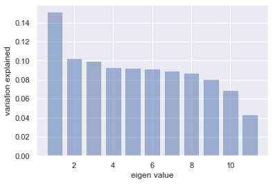

```python
# plot the graph to explain the variance by each variable
plt.bar(list(range(1,12)),pca.explained_variance_ratio_, alpha=0.5,align='center')
plt.ylabel('variation explained')
plt.xlabel('eigen value')
plt.show();
```

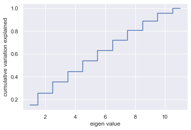

```python
# plot the cumulative sum of variance explained
plt.step(list(range(1,12)),np.cumsum(pca.explained_variance_ratio_), where='mid')
plt.ylabel('cumulative variation explained')
plt.xlabel('eigen value')
plt.show();
```

```python
# fit the scaled dataset and transform it
pca9 = PCA(n_components=9) # 90% of variance is explained by 9 components
pca9.fit(X_train)
pca9_transformed = pca9.transform(X_train)
```

```python
# convert the resulting array into a dataframe
df_pca = pd.DataFrame(pca9_transformed)
df_pca.head()
```

|  | 0 | 1 | 2 | 3 | 4 | 5 | 6 | 7 | 8 |
| --- | --- | --- | --- | --- | --- | --- | --- | --- | --- |
| 0 | -1.158707 | -1.034118 | 0.444031 | -0.336153 | 0.695988 | 1.305602 | 0.217977 | -1.341234 | -0.456598 |
| 1 | 1.459892 | -0.709976 | 1.040002 | -0.071412 | 0.930184 | 0.875535 | 0.628143 | -1.790392 | 0.040279 |
| 2 | -0.514922 | 0.920822 | -2.637822 | -0.348129 | -0.326699 | -0.530706 | 0.310746 | -0.800537 | -0.133608 |
| 3 | 0.727682 | -0.811734 | -1.928907 | 1.480349 | 0.691956 | -0.239865 | -0.747301 | 0.124263 | -0.930684 |
| 4 | 0.924222 | 1.236708 | -0.780374 | 0.553053 | 1.107829 | -0.149671 | 1.496253 | 2.266254 | 1.143687 |

**Applying PCA on the dataset shows us that 90% of the variance is explained by 10 independent variables which doesn't result in dimensionality reduction.**

The EDA indicated that there was not much multi-collinearity between the features.

**We will use the scaled raw dataset and the upsampled raw dataset for ANN model training and testing**

## Deliverable – 6: Initialize & build the model. Identify the points of improvement and implement the same.(20 points)

**6.1 Base Artificial neural network initiation**

The Base ANN model will consist of 2 hidden layers and an output layer

```python
# initialize the constructor
base_model = Sequential()
```

```python
# hidden layer 1
base_model.add(Dense(12, input_shape = (X.shape[1],), activation = 'relu', kernel_initializer = 'uniform'))
# hidden layer 2
base_model.add(Dense(6, activation='tanh'))
# output layer
base_model.add(Dense(1, activation='sigmoid')) # one neuron for binary classification
# optimizer function
optimizer = tf.keras.optimizers.Adam(lr = 0.001) # learning rate is 0.001
# compile model
base_model.compile(loss = 'binary_crossentropy',optimizer=optimizer, metrics = ['accuracy'])
```

```python
# model summary
base_model.summary()
```

```
Model: "sequential"
_________________________________________________________________
Layer (type)                 Output Shape              Param #
=================================================================
dense (Dense)                (None, 12)                144
_________________________________________________________________
dense_1 (Dense)              (None, 6)                 78
_________________________________________________________________
dense_2 (Dense)              (None, 1)                 7
=================================================================
Total params: 229
Trainable params: 229
Non-trainable params: 0
_________________________________________________________________
```

```python
# train the model with training set.
epochs = 50
batch_size = 500
# pass 2 train data sets one corresponding to raw dataset and the other to upsampled dataset
trainX = [X_train, X_train_res]
trainY = [y_train, y_train_res]

for i in range(len(trainX)):
    # fit data to the ANN model
    # 20% of training data is used for validation set
    history = base_model.fit(trainX[i],
                        trainY[i],
                        epochs=epochs,
                        batch_size = batch_size,
                        validation_split = 0.2,
                        verbose = False) # validation dataset is 20% of train dataset

    hist  = pd.DataFrame(history.history)
    hist['epoch'] = history.epoch
    print(hist)
```

```
        loss  accuracy  val_loss  val_accuracy  epoch
0   0.679471  0.675937  0.659438      0.799375      0
1   0.646237  0.795937  0.627128      0.800625      1
2   0.615993  0.793281  0.597043      0.800000      2
3   0.587190  0.793281  0.567392      0.799375      3
4   0.559063  0.793281  0.538802      0.800000      4
5   0.532496  0.793281  0.513117      0.800625      5
6   0.509530  0.793594  0.491085      0.801875      6
7   0.489790  0.795000  0.473511      0.804375      7
8   0.474164  0.796875  0.459413      0.808750      8
9   0.461528  0.802188  0.448295      0.814375      9
10  0.451533  0.806250  0.439247      0.816875     10
11  0.443128  0.812187  0.431884      0.817500     11
12  0.436099  0.814844  0.425716      0.820625     12
13  0.430059  0.815625  0.420603      0.823750     13
```

[output cut: 87 more lines]

**Based on the training and validation set, we see that the scaled raw data has a better accuracy than the Upsampled data set. Henceforth, we will be using the raw scaled dataset for all model performance evaluation and tuning**

```python
# fit raw training dataset to the ANN model
# 20% of training data is used for validation of model
history = base_model.fit(X_train,
                        y_train,
                        epochs=epochs,
                        batch_size = batch_size,
                        validation_split = 0.2,
                        verbose = False)
hist_1  = pd.DataFrame(history.history)
hist_1['epoch'] = history.epoch
print(hist_1)
```

```
        loss  accuracy  val_loss  val_accuracy  epoch
0   0.354096  0.852656  0.327983      0.858750      0
1   0.333236  0.862813  0.328865      0.863125      1
2   0.332601  0.862969  0.327403      0.861250      2
3   0.330955  0.862813  0.327184      0.860000      3
4   0.330623  0.862969  0.327940      0.860000      4
5   0.330252  0.863750  0.328271      0.860000      5
6   0.329998  0.863594  0.328294      0.858750      6
7   0.329985  0.863437  0.328423      0.860000      7
8   0.329897  0.864219  0.328339      0.856875      8
9   0.329375  0.864531  0.329067      0.857500      9
10  0.329229  0.865313  0.328893      0.859375     10
11  0.329108  0.864375  0.328725      0.857500     11
12  0.329198  0.864062  0.328751      0.857500     12
13  0.329005  0.864688  0.329170      0.860000     13
```

[output cut: 36 more lines]

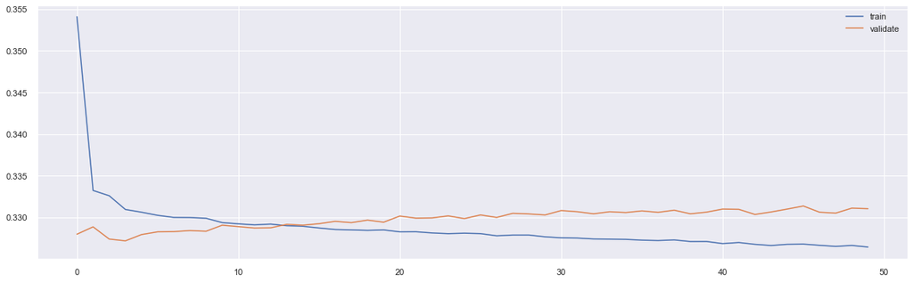

```python
# plot loss vs epochs
plt.figure(figsize=(20,6))
plt.plot(hist_1['loss'])
plt.plot(hist_1['val_loss'])
plt.legend(('train','validate'),loc=0)
plt.show();
```

The loss after 12 epochs increased for the validation set which indicates that the model is trying to overfit the data. This is not an ideal model for production. Hence, hyperparameter tuning is necessary for arriving at the right model

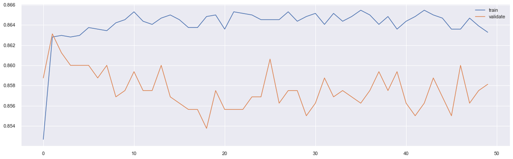

```python
# plot accuracy vs epochs
plt.figure(figsize=(20,6))
plt.plot(hist_1['accuracy'])
plt.plot(hist_1['val_accuracy'])
plt.legend(('train','validate'),loc=0)
plt.show();
```

```python
# print loss and accuracy for the test dataset for base model
loss, acc = base_model.evaluate(X_test, y_test, verbose=0)
print('Accuracy: %.3f'  % acc)
print('Loss: %.3f' % loss)
```

```
Accuracy: 0.862
Loss: 0.338
```

```python
# predict the dependent variable
y_predict = base_model.predict(X_test)
y_predict
```

```
array([[0.03623298],
       [0.02603456],
       [0.10860938],
       ...,
       [0.709978  ],
       [0.10554066],
       [0.24358982]], dtype=float32)
```

```python
# calculate the performance metrics of the base model
acc = base_model.evaluate(X_test,y_test, verbose=0)[1]
recall = recall_score(y_test, y_predict)
precision = precision_score(y_test, y_predict)
f1 = f1_score(y_test, y_predict)
```

```python
# confusion matrix for base model
y_predict = (base_model.predict(X_test) > 0.5).astype("int32")
print('Accuracy base model: ' + str(acc))
print('Recall score model: ' + str(recall))
print('Precision score base model: ' + str(precision))
print('f1 score base model: ' + str(f1))

confusion_matrix(y_test, y_predict)
```

```
Accuracy base model: 0.8615000247955322
Recall score model: 0.46564885496183206
Precision score base model: 0.732
f1 score base model: 0.5692068429237946
```

```
array([[1540,   67],
       [ 210,  183]])
```

```python
# capture the performance metrics of the base model in a dataframe
metrics_base = pd.DataFrame({'Model':['Base ANN'],
                             'Accuracy':acc,
                             'Recall':recall,
                             'Precision':precision,
                             'F1 Score':f1})

metrics_base
```

|  | Model | Accuracy | Recall | Precision | F1 Score |
| --- | --- | --- | --- | --- | --- |
| 0 | Base ANN | 0.8615 | 0.465649 | 0.732 | 0.569207 |

**6.2 Hyperparameter tuning**

The following Hyperparameters will be considered for optimization:

1. Epochs
2. Batch Size
3. Optimizer Function
4. Learning Rate
5. Hidden Layer Neurons
6. Activation Function
7. Drop Out Rate
8. Momentum
9. Weight Initialization

**6.2.1 Tune batch size and number of epochs**

```python
 # Use scikit-learn to grid search the batch size and epochs
from sklearn.model_selection import GridSearchCV
from keras.wrappers.scikit_learn import KerasClassifier

# Function to create model, required for KerasClassifier
def create_model():
    # create model
    model = Sequential()
    model.add(Dense(12, input_dim=11, activation='relu'))
    model.add(Dense(1, activation='sigmoid'))
    # Compile model
    model.compile(loss='binary_crossentropy', optimizer='adam', metrics=['accuracy'])
    return model

# fix random seed for reproducibility
seed = 7
np.random.seed(seed)

# create model
model = KerasClassifier(build_fn=create_model, verbose=0)

# define the grid search parameters
batch_size = [10, 20, 40, 60, 80, 100, 200, 500, 1000]
epochs = [10, 20, 50, 100, 200, 500]
param_grid = dict(batch_size=batch_size, epochs=epochs)
grid = GridSearchCV(estimator=model, param_grid=param_grid, n_jobs=-1, cv=5)
grid_result = grid.fit(X_train, y_train)

# summarize results
print("Best: %f using %s" % (grid_result.best_score_, grid_result.best_params_))
means = grid_result.cv_results_['mean_test_score']
stds = grid_result.cv_results_['std_test_score']
params = grid_result.cv_results_['params']
for mean, stdev, param in zip(means, stds, params):
    print("%f (%f) with: %r" % (mean, stdev, param))
```

```
Best: 0.859000 using {'batch_size': 100, 'epochs': 200}
0.855750 (0.008352) with: {'batch_size': 10, 'epochs': 10}
0.856625 (0.008897) with: {'batch_size': 10, 'epochs': 20}
0.857750 (0.011212) with: {'batch_size': 10, 'epochs': 50}
0.857375 (0.009948) with: {'batch_size': 10, 'epochs': 100}
0.858750 (0.011047) with: {'batch_size': 10, 'epochs': 200}
0.856125 (0.009274) with: {'batch_size': 10, 'epochs': 500}
0.844625 (0.013605) with: {'batch_size': 20, 'epochs': 10}
0.856250 (0.010876) with: {'batch_size': 20, 'epochs': 20}
0.858000 (0.009686) with: {'batch_size': 20, 'epochs': 50}
0.858125 (0.011852) with: {'batch_size': 20, 'epochs': 100}
0.855250 (0.011710) with: {'batch_size': 20, 'epochs': 200}
0.855625 (0.009699) with: {'batch_size': 20, 'epochs': 500}
0.835750 (0.008008) with: {'batch_size': 40, 'epochs': 10}
0.856000 (0.012903) with: {'batch_size': 40, 'epochs': 20}
0.856250 (0.011812) with: {'batch_size': 40, 'epochs': 50}
0.858750 (0.010047) with: {'batch_size': 40, 'epochs': 100}
0.858625 (0.010484) with: {'batch_size': 40, 'epochs': 200}
0.855875 (0.009475) with: {'batch_size': 40, 'epochs': 500}
0.832875 (0.016917) with: {'batch_size': 60, 'epochs': 10}
0.850750 (0.009909) with: {'batch_size': 60, 'epochs': 20}
0.855000 (0.011497) with: {'batch_size': 60, 'epochs': 50}
0.857625 (0.010922) with: {'batch_size': 60, 'epochs': 100}
0.854500 (0.010907) with: {'batch_size': 60, 'epochs': 200}
0.858625 (0.011253) with: {'batch_size': 60, 'epochs': 500}
0.825000 (0.010023) with: {'batch_size': 80, 'epochs': 10}
0.844500 (0.010821) with: {'batch_size': 80, 'epochs': 20}
0.850875 (0.008344) with: {'batch_size': 80, 'epochs': 50}
0.856500 (0.010183) with: {'batch_size': 80, 'epochs': 100}
0.857375 (0.009095) with: {'batch_size': 80, 'epochs': 200}
0.857250 (0.011763) with: {'batch_size': 80, 'epochs': 500}
0.818625 (0.016842) with: {'batch_size': 100, 'epochs': 10}
0.846500 (0.012378) with: {'batch_size': 100, 'epochs': 20}
0.850875 (0.017485) with: {'batch_size': 100, 'epochs': 50}
0.858125 (0.011477) with: {'batch_size': 100, 'epochs': 100}
0.859000 (0.010670) with: {'batch_size': 100, 'epochs': 200}
0.857500 (0.009803) with: {'batch_size': 100, 'epochs': 500}
0.808500 (0.015615) with: {'batch_size': 200, 'epochs': 10}
0.823125 (0.008750) with: {'batch_size': 200, 'epochs': 20}
0.850000 (0.013116) with: {'batch_size': 200, 'epochs': 50}
0.857625 (0.008027) with: {'batch_size': 200, 'epochs': 100}
0.854875 (0.011855) with: {'batch_size': 200, 'epochs': 200}
0.855750 (0.011287) with: {'batch_size': 200, 'epochs': 500}
0.747000 (0.025640) with: {'batch_size': 500, 'epochs': 10}
0.806875 (0.009152) with: {'batch_size': 500, 'epochs': 20}
0.829750 (0.019144) with: {'batch_size': 500, 'epochs': 50}
0.851500 (0.016614) with: {'batch_size': 500, 'epochs': 100}
0.858250 (0.010727) with: {'batch_size': 500, 'epochs': 200}
0.858625 (0.009980) with: {'batch_size': 500, 'epochs': 500}
0.682125 (0.046695) with: {'batch_size': 1000, 'epochs': 10}
0.774000 (0.031917) with: {'batch_size': 1000, 'epochs': 20}
0.804750 (0.013582) with: {'batch_size': 1000, 'epochs': 50}
0.829750 (0.018984) with: {'batch_size': 1000, 'epochs': 100}
0.851750 (0.012884) with: {'batch_size': 1000, 'epochs': 200}
0.857750 (0.009958) with: {'batch_size': 1000, 'epochs': 500}
```

The best batch size and epoch for the ANN model are:  
'batch_size': 100, 'epochs': 200

**6.2.2 Tune training optimization algorithm**

```python
# Function to create model, required for KerasClassifier
def create_model(optimizer='adam'):
    # create model
    model = Sequential()
    model.add(Dense(12, input_dim=11, activation='relu'))
    model.add(Dense(1, activation='sigmoid'))
    # Compile model
    model.compile(loss='binary_crossentropy', optimizer=optimizer, metrics=['accuracy'])
    return model

# fix random seed for reproducibility
seed = 7
np.random.seed(seed)

# create model
model = KerasClassifier(build_fn=create_model, epochs=100, batch_size=500, verbose=0)
# define the grid search parameters
optimizer = ['SGD', 'RMSprop', 'Adagrad', 'Adadelta', 'Adam', 'Adamax', 'Nadam']
param_grid = dict(optimizer=optimizer)
grid = GridSearchCV(estimator=model, param_grid=param_grid, n_jobs=-1, cv=3)
grid_result = grid.fit(X_train, y_train)

# summarize results
print("Best: %f using %s" % (grid_result.best_score_, grid_result.best_params_))
means = grid_result.cv_results_['mean_test_score']
stds = grid_result.cv_results_['std_test_score']
params = grid_result.cv_results_['params']
for mean, stdev, param in zip(means, stds, params):
    print("%f (%f) with: %r" % (mean, stdev, param))
```

```
Best: 0.850999 using {'optimizer': 'RMSprop'}
0.811875 (0.001351) with: {'optimizer': 'SGD'}
0.850999 (0.003154) with: {'optimizer': 'RMSprop'}
0.714250 (0.044563) with: {'optimizer': 'Adagrad'}
0.438370 (0.129174) with: {'optimizer': 'Adadelta'}
0.844124 (0.005301) with: {'optimizer': 'Adam'}
0.814376 (0.004480) with: {'optimizer': 'Adamax'}
0.845499 (0.009843) with: {'optimizer': 'Nadam'}
```

The best optimizer algorithm for the ANN model is:  
'optimizer': 'RMSprop'

**6.2.3 Tune learning rate and momentum**

```python
from keras.optimizers import SGD
# Function to create model, required for KerasClassifier
def create_model(learn_rate=0.01, momentum=0):
    # create model
    model = Sequential()
    model.add(Dense(12, input_dim=11, activation='relu'))
    model.add(Dense(1, activation='sigmoid'))
    # Compile model
    optimizer = SGD(lr=learn_rate, momentum=momentum)
    model.compile(loss='binary_crossentropy', optimizer=optimizer, metrics=['accuracy'])
    return model

# fix random seed for reproducibility
seed = 7
np.random.seed(seed)

# create model
model = KerasClassifier(build_fn=create_model, epochs=100, batch_size=500, verbose=0)
# define the grid search parameters
learn_rate = [0.00001, 0.001, 0.01, 0.1, 0.2, 0.3]
momentum = [0.0, 0.2, 0.4, 0.6, 0.8, 0.9]
param_grid = dict(learn_rate=learn_rate, momentum=momentum)
grid = GridSearchCV(estimator=model, param_grid=param_grid, n_jobs=-1, cv=3)
grid_result = grid.fit(X_train, y_train)

# summarize results
print("Best: %f using %s" % (grid_result.best_score_, grid_result.best_params_))
means = grid_result.cv_results_['mean_test_score']
stds = grid_result.cv_results_['std_test_score']
params = grid_result.cv_results_['params']
for mean, stdev, param in zip(means, stds, params):
    print("%f (%f) with: %r" % (mean, stdev, param))
```

```
Best: 0.858874 using {'learn_rate': 0.1, 'momentum': 0.6}
0.569143 (0.139515) with: {'learn_rate': 1e-05, 'momentum': 0.0}
0.586895 (0.120002) with: {'learn_rate': 1e-05, 'momentum': 0.2}
0.408476 (0.163051) with: {'learn_rate': 1e-05, 'momentum': 0.4}
0.559238 (0.074092) with: {'learn_rate': 1e-05, 'momentum': 0.6}
0.532362 (0.079073) with: {'learn_rate': 1e-05, 'momentum': 0.8}
0.325873 (0.020792) with: {'learn_rate': 1e-05, 'momentum': 0.9}
0.757124 (0.010564) with: {'learn_rate': 0.001, 'momentum': 0.0}
0.771502 (0.018190) with: {'learn_rate': 0.001, 'momentum': 0.2}
0.769626 (0.012090) with: {'learn_rate': 0.001, 'momentum': 0.4}
0.791999 (0.007311) with: {'learn_rate': 0.001, 'momentum': 0.6}
0.796750 (0.003218) with: {'learn_rate': 0.001, 'momentum': 0.8}
0.798999 (0.003705) with: {'learn_rate': 0.001, 'momentum': 0.9}
0.806000 (0.001546) with: {'learn_rate': 0.01, 'momentum': 0.0}
0.805250 (0.001717) with: {'learn_rate': 0.01, 'momentum': 0.2}
0.805875 (0.003392) with: {'learn_rate': 0.01, 'momentum': 0.4}
0.813001 (0.004617) with: {'learn_rate': 0.01, 'momentum': 0.6}
0.829499 (0.003388) with: {'learn_rate': 0.01, 'momentum': 0.8}
0.852874 (0.005515) with: {'learn_rate': 0.01, 'momentum': 0.9}
0.853124 (0.006694) with: {'learn_rate': 0.1, 'momentum': 0.0}
0.855750 (0.001577) with: {'learn_rate': 0.1, 'momentum': 0.2}
0.857124 (0.006796) with: {'learn_rate': 0.1, 'momentum': 0.4}
0.858874 (0.004618) with: {'learn_rate': 0.1, 'momentum': 0.6}
0.858249 (0.007642) with: {'learn_rate': 0.1, 'momentum': 0.8}
0.857374 (0.003653) with: {'learn_rate': 0.1, 'momentum': 0.9}
0.855624 (0.004280) with: {'learn_rate': 0.2, 'momentum': 0.0}
0.855999 (0.005637) with: {'learn_rate': 0.2, 'momentum': 0.2}
0.857249 (0.004781) with: {'learn_rate': 0.2, 'momentum': 0.4}
0.857749 (0.007202) with: {'learn_rate': 0.2, 'momentum': 0.6}
0.858124 (0.004772) with: {'learn_rate': 0.2, 'momentum': 0.8}
0.855375 (0.004700) with: {'learn_rate': 0.2, 'momentum': 0.9}
0.855124 (0.005350) with: {'learn_rate': 0.3, 'momentum': 0.0}
0.856624 (0.005013) with: {'learn_rate': 0.3, 'momentum': 0.2}
0.854999 (0.007377) with: {'learn_rate': 0.3, 'momentum': 0.4}
0.856874 (0.005169) with: {'learn_rate': 0.3, 'momentum': 0.6}
0.856999 (0.007134) with: {'learn_rate': 0.3, 'momentum': 0.8}
0.856249 (0.005505) with: {'learn_rate': 0.3, 'momentum': 0.9}
```

The best learning rate and momentum for the ANN model are:  
'learn_rate': 0.1, 'momentum': 0.6

**6.2.4 Tune network weight initilization**

```python
# Function to create model, required for KerasClassifier
def create_model(init_mode='uniform'):
    # create model
    model = Sequential()
    model.add(Dense(12, input_dim=11, kernel_initializer=init_mode, activation='relu'))
    model.add(Dense(1, kernel_initializer=init_mode, activation='sigmoid'))
    # Compile model
    model.compile(loss='binary_crossentropy', optimizer='adam', metrics=['accuracy'])
    return model

# fix random seed for reproducibility
seed = 7
np.random.seed(seed)

# create model
model = KerasClassifier(build_fn=create_model, epochs=100, batch_size=500, verbose=0)
# define the grid search parameters
init_mode = ['uniform', 'lecun_uniform', 'normal', 'zero', 'glorot_normal', 'glorot_uniform', 'he_normal', 'he_uniform']
param_grid = dict(init_mode=init_mode)
grid = GridSearchCV(estimator=model, param_grid=param_grid, n_jobs=-1, cv=3)
grid_result = grid.fit(X_train, y_train)

# summarize results
print("Best: %f using %s" % (grid_result.best_score_, grid_result.best_params_))
means = grid_result.cv_results_['mean_test_score']
stds = grid_result.cv_results_['std_test_score']
params = grid_result.cv_results_['params']
for mean, stdev, param in zip(means, stds, params):
    print("%f (%f) with: %r" % (mean, stdev, param))
```

```
Best: 0.848249 using {'init_mode': 'glorot_normal'}
0.836874 (0.009826) with: {'init_mode': 'uniform'}
0.842750 (0.010013) with: {'init_mode': 'lecun_uniform'}
0.839751 (0.013225) with: {'init_mode': 'normal'}
0.794500 (0.002345) with: {'init_mode': 'zero'}
0.848249 (0.003301) with: {'init_mode': 'glorot_normal'}
0.845000 (0.003597) with: {'init_mode': 'glorot_uniform'}
0.837874 (0.007012) with: {'init_mode': 'he_normal'}
0.827625 (0.008726) with: {'init_mode': 'he_uniform'}
```

The best weight initialization option is:  
'init_mode': 'glorot_normal'

**6.2.5 Tune Neuron activation function**

```python
# Function to create model, required for KerasClassifier
def create_model(activation='relu'):
    # create model
    model = Sequential()
    model.add(Dense(12, input_dim=11, kernel_initializer='uniform', activation=activation))
    model.add(Dense(1, kernel_initializer='uniform', activation='sigmoid'))
    # Compile model
    model.compile(loss='binary_crossentropy', optimizer='adam', metrics=['accuracy'])
    return model

# fix random seed for reproducibility
seed = 7
np.random.seed(seed)

# create model
model = KerasClassifier(build_fn=create_model, epochs=100, batch_size=500, verbose=0)
# define the grid search parameters
activation = ['softmax', 'softplus', 'softsign', 'relu', 'tanh', 'sigmoid', 'hard_sigmoid', 'linear']
param_grid = dict(activation=activation)
grid = GridSearchCV(estimator=model, param_grid=param_grid, n_jobs=-1, cv=3)
grid_result = grid.fit(X_train, y_train)

# summarize results
print("Best: %f using %s" % (grid_result.best_score_, grid_result.best_params_))
means = grid_result.cv_results_['mean_test_score']
stds = grid_result.cv_results_['std_test_score']
params = grid_result.cv_results_['params']
for mean, stdev, param in zip(means, stds, params):
    print("%f (%f) with: %r" % (mean, stdev, param))
```

```
Best: 0.832875 using {'activation': 'softsign'}
0.794500 (0.002345) with: {'activation': 'softmax'}
0.794250 (0.002329) with: {'activation': 'softplus'}
0.832875 (0.000490) with: {'activation': 'softsign'}
0.814501 (0.013866) with: {'activation': 'relu'}
0.830125 (0.002484) with: {'activation': 'tanh'}
0.794500 (0.002345) with: {'activation': 'sigmoid'}
0.794500 (0.002345) with: {'activation': 'hard_sigmoid'}
0.811876 (0.004271) with: {'activation': 'linear'}
```

The best activation function for the ANN model is:  
'activation': 'softsign'

**6.2.6 Tune dropout regularization**

```python
from keras.layers import Dropout
from keras.constraints import maxnorm

# Function to create model, required for KerasClassifier
def create_model(dropout_rate=0.0, weight_constraint=0):
    # create model
    model = Sequential()
    model.add(Dense(12, input_dim=11, kernel_initializer='uniform', activation='linear', kernel_constraint=maxnorm(weight_constraint)))
    model.add(Dropout(dropout_rate))
    model.add(Dense(1, kernel_initializer='uniform', activation='sigmoid'))
    # Compile model
    model.compile(loss='binary_crossentropy', optimizer='adam', metrics=['accuracy'])
    return model

# fix random seed for reproducibility
seed = 7
np.random.seed(seed)

# create model
model = KerasClassifier(build_fn=create_model, epochs=100, batch_size=10, verbose=0)
# define the grid search parameters
weight_constraint = [1, 2, 3, 4, 5]
dropout_rate = [0.0, 0.1, 0.2, 0.3, 0.4, 0.5, 0.6, 0.7, 0.8, 0.9]
param_grid = dict(dropout_rate=dropout_rate, weight_constraint=weight_constraint)
grid = GridSearchCV(estimator=model, param_grid=param_grid, n_jobs=-1, cv=3)
grid_result = grid.fit(X_train, y_train)

# summarize results
print("Best: %f using %s" % (grid_result.best_score_, grid_result.best_params_))
means = grid_result.cv_results_['mean_test_score']
stds = grid_result.cv_results_['std_test_score']
params = grid_result.cv_results_['params']
for mean, stdev, param in zip(means, stds, params):
    print("%f (%f) with: %r" % (mean, stdev, param))
```

```
Best: 0.812376 using {'dropout_rate': 0.1, 'weight_constraint': 3}
0.811501 (0.004262) with: {'dropout_rate': 0.0, 'weight_constraint': 1}
0.811751 (0.003682) with: {'dropout_rate': 0.0, 'weight_constraint': 2}
0.811376 (0.003339) with: {'dropout_rate': 0.0, 'weight_constraint': 3}
0.811501 (0.005180) with: {'dropout_rate': 0.0, 'weight_constraint': 4}
0.812126 (0.004682) with: {'dropout_rate': 0.0, 'weight_constraint': 5}
0.810501 (0.004432) with: {'dropout_rate': 0.1, 'weight_constraint': 1}
0.811126 (0.004646) with: {'dropout_rate': 0.1, 'weight_constraint': 2}
0.812376 (0.005331) with: {'dropout_rate': 0.1, 'weight_constraint': 3}
0.811626 (0.003969) with: {'dropout_rate': 0.1, 'weight_constraint': 4}
0.811751 (0.004418) with: {'dropout_rate': 0.1, 'weight_constraint': 5}
0.811501 (0.003799) with: {'dropout_rate': 0.2, 'weight_constraint': 1}
0.811876 (0.003826) with: {'dropout_rate': 0.2, 'weight_constraint': 2}
0.811876 (0.004554) with: {'dropout_rate': 0.2, 'weight_constraint': 3}
0.811001 (0.003792) with: {'dropout_rate': 0.2, 'weight_constraint': 4}
0.811001 (0.003280) with: {'dropout_rate': 0.2, 'weight_constraint': 5}
0.811375 (0.003199) with: {'dropout_rate': 0.3, 'weight_constraint': 1}
0.810626 (0.003499) with: {'dropout_rate': 0.3, 'weight_constraint': 2}
0.810125 (0.002813) with: {'dropout_rate': 0.3, 'weight_constraint': 3}
0.811751 (0.004485) with: {'dropout_rate': 0.3, 'weight_constraint': 4}
0.812126 (0.002888) with: {'dropout_rate': 0.3, 'weight_constraint': 5}
0.810501 (0.003917) with: {'dropout_rate': 0.4, 'weight_constraint': 1}
0.810751 (0.003799) with: {'dropout_rate': 0.4, 'weight_constraint': 2}
0.811126 (0.004046) with: {'dropout_rate': 0.4, 'weight_constraint': 3}
0.810251 (0.004087) with: {'dropout_rate': 0.4, 'weight_constraint': 4}
0.810751 (0.003846) with: {'dropout_rate': 0.4, 'weight_constraint': 5}
0.811750 (0.003288) with: {'dropout_rate': 0.5, 'weight_constraint': 1}
0.811126 (0.003956) with: {'dropout_rate': 0.5, 'weight_constraint': 2}
0.810376 (0.003450) with: {'dropout_rate': 0.5, 'weight_constraint': 3}
0.810251 (0.003196) with: {'dropout_rate': 0.5, 'weight_constraint': 4}
0.809375 (0.002911) with: {'dropout_rate': 0.5, 'weight_constraint': 5}
0.810376 (0.003661) with: {'dropout_rate': 0.6, 'weight_constraint': 1}
0.811626 (0.003516) with: {'dropout_rate': 0.6, 'weight_constraint': 2}
0.811125 (0.002862) with: {'dropout_rate': 0.6, 'weight_constraint': 3}
0.810250 (0.002689) with: {'dropout_rate': 0.6, 'weight_constraint': 4}
0.809376 (0.004261) with: {'dropout_rate': 0.6, 'weight_constraint': 5}
0.811375 (0.002920) with: {'dropout_rate': 0.7, 'weight_constraint': 1}
0.811126 (0.003382) with: {'dropout_rate': 0.7, 'weight_constraint': 2}
0.810375 (0.002285) with: {'dropout_rate': 0.7, 'weight_constraint': 3}
0.810250 (0.000890) with: {'dropout_rate': 0.7, 'weight_constraint': 4}
0.810375 (0.002141) with: {'dropout_rate': 0.7, 'weight_constraint': 5}
0.808750 (0.000889) with: {'dropout_rate': 0.8, 'weight_constraint': 1}
0.808125 (0.000798) with: {'dropout_rate': 0.8, 'weight_constraint': 2}
0.807750 (0.001839) with: {'dropout_rate': 0.8, 'weight_constraint': 3}
0.807125 (0.000320) with: {'dropout_rate': 0.8, 'weight_constraint': 4}
0.809000 (0.001308) with: {'dropout_rate': 0.8, 'weight_constraint': 5}
0.801500 (0.000648) with: {'dropout_rate': 0.9, 'weight_constraint': 1}
0.800249 (0.004537) with: {'dropout_rate': 0.9, 'weight_constraint': 2}
0.800375 (0.001432) with: {'dropout_rate': 0.9, 'weight_constraint': 3}
0.800375 (0.001181) with: {'dropout_rate': 0.9, 'weight_constraint': 4}
0.798499 (0.003419) with: {'dropout_rate': 0.9, 'weight_constraint': 5}
```

The best drop out rate and weight constraint for the ANN model are:  
'dropout_rate': 0.1, 'weight_constraint': 3

**6.2.7 Tune number of neurons in hidden layer**

```python
# Function to create model, required for KerasClassifier
def create_model(neurons=1):
    # create model
    model = Sequential()
    model.add(Dense(neurons, input_dim=11, kernel_initializer='uniform', activation='linear', kernel_constraint=maxnorm(4)))
    model.add(Dropout(0.2))
    model.add(Dense(1, kernel_initializer='uniform', activation='sigmoid'))
    # Compile model
    model.compile(loss='binary_crossentropy', optimizer='adam', metrics=['accuracy'])
    return model

# fix random seed for reproducibility
seed = 7
np.random.seed(seed)

# create model
model = KerasClassifier(build_fn=create_model, epochs=100, batch_size=10, verbose=0)
# define the grid search parameters
neurons = [1,3, 5, 6, 10, 15, 20, 25, 30, ]
param_grid = dict(neurons=neurons)
grid = GridSearchCV(estimator=model, param_grid=param_grid, n_jobs=-1, cv=3)
grid_result = grid.fit(X_train, y_train)

# summarize results
print("Best: %f using %s" % (grid_result.best_score_, grid_result.best_params_))
means = grid_result.cv_results_['mean_test_score']
stds = grid_result.cv_results_['std_test_score']
params = grid_result.cv_results_['params']
for mean, stdev, param in zip(means, stds, params):
    print("%f (%f) with: %r" % (mean, stdev, param))
```

```
Best: 0.812126 using {'neurons': 30}
0.808375 (0.001044) with: {'neurons': 1}
0.810001 (0.003450) with: {'neurons': 3}
0.810751 (0.003243) with: {'neurons': 5}
0.810876 (0.003111) with: {'neurons': 6}
0.810751 (0.004192) with: {'neurons': 10}
0.809626 (0.003846) with: {'neurons': 15}
0.811001 (0.003682) with: {'neurons': 20}
0.811001 (0.004289) with: {'neurons': 25}
0.812126 (0.003077) with: {'neurons': 30}
```

The optimal number of neurons int he hidden layer are:  
'neurons': 30

## Deliverable – 7: Predict the results using 0.5 as a threshold (10 points)

**7.1 Tuned Hyperparameters for the final model**

```python
# initialize the hyperparameters based on the tuning exercise
batch_size_1 = 100
epochs_1 = 200
optimizer_1 = tf.keras.optimizers.RMSprop(learning_rate = 0.1, momentum = 0.6)
init_mode_1 = 'glorot_normal'
activation_1 = 'softsign'
dropout_rate = 0.1
weight_constraint = 3
```

**7.2 Final ANN Model after tuning hyperparameters**

```python
# initialize the constructor
final_model = Sequential()
# hidden layer 1
final_model.add(Dense(30, input_dim = 11,
                      activation = activation_1,
                      kernel_initializer = init_mode_1,
                      kernel_constraint=maxnorm(weight_constraint)))
final_model.add(Dropout(dropout_rate))
# output layer
final_model.add(Dense(1, activation='sigmoid'))

# compile model
final_model.compile(loss = 'binary_crossentropy',optimizer=optimizer_1, metrics = ['accuracy'])
```

```python
# model summary
final_model.summary()
```

```
Model: "sequential_1"
_________________________________________________________________
Layer (type)                 Output Shape              Param #
=================================================================
dense_3 (Dense)              (None, 30)                360
_________________________________________________________________
dropout (Dropout)            (None, 30)                0
_________________________________________________________________
dense_4 (Dense)              (None, 1)                 31
=================================================================
Total params: 391
Trainable params: 391
Non-trainable params: 0
_________________________________________________________________
```

```python
# fit the raw data to the final model
# 20% of training data is reserved for validation
history = final_model.fit(X_train,
                        y_train,
                        epochs=epochs_1,
                        batch_size = batch_size_1,
                        validation_split = 0.2,
                        verbose = False)
hist_final  = pd.DataFrame(history.history)
hist_final['epoch'] = history.epoch
print(hist_final)
```

```
         loss  accuracy  val_loss  val_accuracy  epoch
0    0.486313  0.794375  0.485682      0.793750      0
1    0.444119  0.815469  0.424111      0.826250      1
2    0.442281  0.812031  0.404732      0.840000      2
3    0.437416  0.813438  0.381459      0.831875      3
4    0.429397  0.821406  0.409540      0.829375      4
..        ...       ...       ...           ...    ...
195  0.428419  0.816875  0.430566      0.798125    195
196  0.423752  0.822500  0.426363      0.840625    196
197  0.433608  0.816719  0.450784      0.785000    197
198  0.420312  0.826563  0.386918      0.825000    198
199  0.423034  0.822187  0.416175      0.830625    199

[200 rows x 5 columns]
```

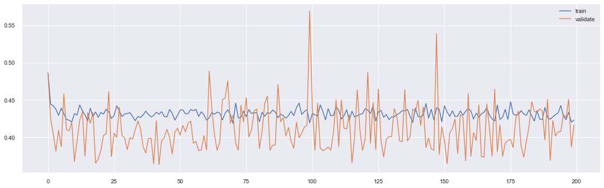

```python
# plot loss vs epochs
plt.figure(figsize=(20,6))
plt.plot(hist_final['loss'])
plt.plot(hist_final['val_loss'])
plt.legend(('train','validate'),loc=0)
plt.show();
```

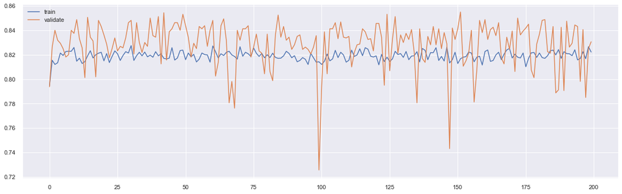

```python
# plot accuracy vs epochs
plt.figure(figsize=(20,6))
plt.plot(hist_final['accuracy'])
plt.plot(hist_final['val_accuracy'])
plt.legend(('train','validate'),loc=0)
plt.show();
```

**7.3 Final ANN Model prediction**

```python
# predict dependent variable using final model
y_predict = final_model.predict(X_test)
y_predict
```

```
array([[0.06083947],
       [0.01102057],
       [0.04887569],
       ...,
       [0.48857087],
       [0.07669309],
       [0.23912   ]], dtype=float32)
```

```python
# predict the results using threshold at 0.5 on the test datasets
y_predict = (final_model.predict(X_test) > 0.5).astype("int32")
y_predict
```

```
array([[0],
       [0],
       [0],
       ...,
       [0],
       [0],
       [0]], dtype=int32)
```

```python
# shape of the predictions
y_predict.shape
```

```
(2000, 1)
```

## Deliverable – 8: Print the Accuracy score and confusion matrix (5 points)

**8.1 Final ANN Model accuracy**

```python
# accuracy of model and loss
loss, acc = final_model.evaluate(X_test, y_test, verbose=0)
print('Accuracy: %.3f'  % acc)
print('Loss: %.3f' % loss)
```

```
Accuracy: 0.840
Loss: 0.409
```

**8.2 Final ANN Model confusion matrix**

```python
# calculate the performance metrics of the base model
acc_final = final_model.evaluate(X_test,y_test, verbose=0)[1]
recall_final = recall_score(y_test, y_predict)
precision_final = precision_score(y_test, y_predict)
f1_final = f1_score(y_test, y_predict)
```

```python
# confusion matrix for final model
y_predict = (final_model.predict(X_test) > 0.5).astype("int32")
cm = confusion_matrix(y_test, y_predict)

print('Accuracy' + str(acc_final))
print('Recall score' + str(recall_final))
print('Precision score' + str(precision_final))
print('f1 score' + str(f1_final))
print(cm)
```

```
Accuracy0.8399999737739563
Recall score0.28498727735368956
Precision score0.7417218543046358
f1 score0.41176470588235287
[[1568   39]
 [ 281  112]]
```

```python
# capture the performance metrics of the final model in a dataframe
metrics_final = pd.DataFrame({'Model':['Final ANN'],
                             'Accuracy':acc_final,
                             'Recall':recall_final,
                             'Precision':precision_final,
                             'F1 Score':f1_final})

metrics_final
```

|  | Model | Accuracy | Recall | Precision | F1 Score |
| --- | --- | --- | --- | --- | --- |
| 0 | Final ANN | 0.84 | 0.284987 | 0.741722 | 0.411765 |

**8.3 Final ANN Model performance score comparision with base ANN model**

```python
# combine the two dataframes to produce a single metrics evaluation dataframe
dfMetrics = pd.concat([metrics_base,metrics_final])

dfMetrics
```

|  | Model | Accuracy | Recall | Precision | F1 Score |
| --- | --- | --- | --- | --- | --- |
| 0 | Base ANN | 0.8615 | 0.465649 | 0.732000 | 0.569207 |
| 0 | Final ANN | 0.8400 | 0.284987 | 0.741722 | 0.411765 |

**8.4 Final ANN Model performance metrics with threshold as 0.25 (EXPERIMENTAL)</b></font>**

```python
# confusion matrix for final model
y_predict_3 = (final_model.predict(X_test) > 0.25).astype("int32")
cm_3 = confusion_matrix(y_test, y_predict)
```

```python
# calculate the performance metrics of the base model
acc_3 = final_model.evaluate(X_test,y_test, verbose=0)[1]
recall_3 = recall_score(y_test, y_predict_3)
precision_3 = precision_score(y_test, y_predict_3)
f1_3 = f1_score(y_test, y_predict_3)



print('Accuracy' + str(acc_3))
print('Recall score' + str(recall_3))
print('Precision score' + str(precision_3))
print('f1 score' + str(f1_3))
print(cm_3)
```

[output not shown]

**8.5 Final ANN Model confusion matrix plot**

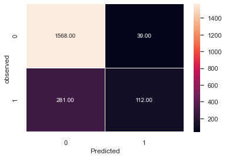

```python
# plot the confusion matrix in terms of heatmap for better visualization.
def draw_cm(actual,predicted):
    cm = confusion_matrix(actual,predicted)
    sns.heatmap(cm,annot=True, linewidth=0.05, fmt='.2f', xticklabels=[0,1], yticklabels=[0,1])
    plt.ylabel('observed')
    plt.xlabel('Predicted')
    plt.show()

# pass parameters in draw_cm function to plot the heatmap.
draw_cm(y_test,y_predict)
```

```python
# calculate sensitivity and specificity
TN=cm[0,0]
TP=cm[1,1]
FN=cm[1,0]
FP=cm[0,1]

fpr = (FP / float(FP+TN))
tpr = (TN / float(TN + FP))
```

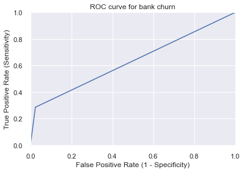

```python
# plotting the AUCROC curve
fpr, tpr, thresholds = roc_curve(y_test, y_predict)
plt.plot(fpr, tpr)
plt.xlim([0.0, 1.0])
plt.ylim([0.0, 1.0])
plt.title('ROC curve for bank churn')
plt.xlabel('False Positive Rate (1 - Specificity)')
plt.ylabel('True Positive Rate (Sensitivity)')
plt.grid(True)
```

**8.5 Conclusion**

```python
# print the metrics for both base model and final model
dfMetrics
```

|  | Model | Accuracy | Recall | Precision | F1 Score |
| --- | --- | --- | --- | --- | --- |
| 0 | Base ANN | 0.8615 | 0.465649 | 0.732000 | 0.569207 |
| 0 | Final ANN | 0.8400 | 0.284987 | 0.741722 | 0.411765 |

1. The base model is an overfit model and the final model is a generalized model. The final model will do better in production as compared to the base model.
2. The final model has 1 hidden layer, which will be a significant factor in deploying in production to avoid larger computational time.
3. The base model gives slightly improved accuracy score compared to the final model
4. @ 0.5 Threshold, the base model has a better recall than the final model but slightly low precision
5. The false negatives (FN) for the final model is higher that the base model. What it means is, the model predicted that the customers will not churn (Leave the bank) but they left the bank.
6. The objective of the model should be to predict with high recall value for the bank churn prediction. The final model though generalized in characteristic, has low recall.
7. Upsampling the dataset using SMOTE didn't improve the predictive power of the model. So, Upsampling as a strategy is not fruitful for this dataset.
8. Since the dataset is an imbalance dataset, a threshold other than 0.5 should be considered. In **section-8.4** I have shown that with a threshold of 0.25, the recall of the model can be improved significantly. What it would mean is, any strategy to retain customers of the bank may go to a large number of customers who are not at risk of churn. Hence the communication has to be slightly generic in nature.